# HW2

Yuri Almeida Cunha

2021-04-07

# Exercise - Fashion MNIST data

The MNIST database is a large database of handwritten digits that is commonly used for training various image processing systems. The black and white images from NIST were normalized to fit into a 28x28 pixel bounding box and anti-aliased, which introduced grayscale levels. The MNIST database contains 60,000 training images and 10,000 testing images.

```r
fashion_mnist <- dataset_fashion_mnist()
x_train <- fashion_mnist$train$x
y_train <- fashion_mnist$train$y
x_test <- fashion_mnist$test$x
y_test <- fashion_mnist$test$y

class_names <- c('T-shirt',
                 'Trouser',
                 'Pullover',
                 'Dress',
                 'Coat',
                 'Sandal',
                 'Shirt',
                 'Sneakers',
                 'Bag',
                 'Boots')
```

## a) Show some example images from the data

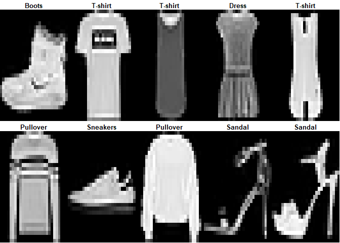

```r
### From the Tension flow documentation

# Divide the plot area into m*n array of subplots
# 2 Lines / 5 Columns
par(mfrow = c(2, 5))

# Mar: A numeric vector of length 4, which sets the margin sizes in the following order: bottom, left, top, and right.
# The default is c(5.1, 4.1, 4.1, 2.1).
# xaxs = 'i' and yaxs = 'i' : Limits of the images lies on the edges of the array subplots
par(mar=c(0, 0, 1.5, 0), xaxs='i', yaxs='i')

for (i in 1:10) {
  img <- x_train[i, , ]
  # Apply the reverse vector on the image matrix columns and transpose
  # This basically "rotates the image for a better visualization
  img <- t(apply(img, 2, rev))
  # Remove the X and Y axis: axes = FALSE / or you could use: xaxt = 'n', yaxt = 'n'
  image(1:28, 1:28, img, col = gray((0:255)/255), axes = FALSE ,
       # add the clothes names to the title
         main = paste(class_names[y_train[i] + 1]))
}
```

```r
# Cloth Types / class numbers
print(unique(y_train))
```

[output not shown]

The for loop above display the first 10 items of the train dataset. The types of the clothes (named here as “classes”) are numbered from 0 to 9. And define which type of clothes we are dealing with.

## b) Train a fully connected deep network to predict items

# Normalizing the data

Important observations:

Data scaling is a recommended pre-processing step when working with deep learning neural networks.  
Data scaling can be achieved by normalizing or standardizing real-valued input and output variables.

A good rule of thumb is that input variables should be small values, probably in the range of 0-1 or standardized with a zero mean and a standard deviation of one.

```r
#### Scaling the axis so that they are between 0 and 1

x_train <- array_reshape(x_train, c(dim(x_train)[1], 784))
x_test <- array_reshape(x_test, c(dim(x_test)[1], 784))

x_train <- as.matrix(x_train) / 255
x_test <- as.matrix(x_test) / 255

####  One-hot encoding for the outcome

y_train <- to_categorical(y_train, 10)
y_test <- to_categorical(y_test, 10)
```

### Bulding our Base Model - base_model

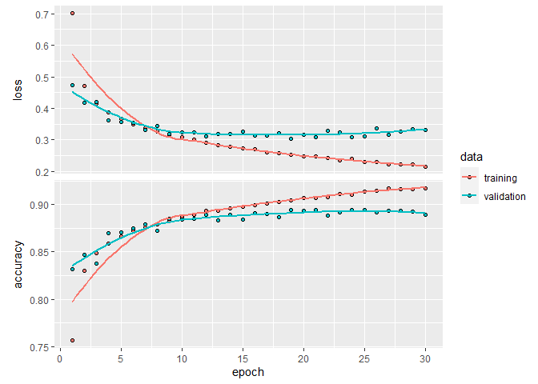

```r
# Activation Functions:

## Linear: The output is same as the input and the function is defined in the range (-infinity, +infinity).
## Unit Step: The output assumes value 0 for negative argument and 1 for positive argument. The range is between (0,1) and the output is binary in nature.
## Sigmoid: This squashes the input to any value between 0 and 1, and makes the model logistic in nature.
## Tanh: This is a nonlinear function, defined in the range of values (-1, 1).The gradient is stronger for tanh than sigmoid.
## ReLU: The range of output is between 0 and infinity.

set.seed(my_seed)
base_model <- keras_model_sequential()
base_model %>%
  # The input_shape argument to the first layer specifies the shape of the input data (a length 784 numeric vector representing a grayscale image).
  # The input shape is the only one you must define, because your model cannot know it. Only you know that, based on your training data.
  # All the other shapes are calculated automatically based on the units and particularities of each layer.
  layer_dense(units = 400, activation = 'relu', input_shape = c(784)) %>% # adding 128 nods
  # Dropout is a technique where randomly selected neurons are ignored during training.
  # They are “dropped-out” randomly. This means that their contribution to the activation of downstream neurons is temporally removed
  # on the forward pass and any weight updates are not applied to the neuron on the backward pass.
  # The effect is that the network becomes less sensitive to the specific weights of neurons.
  # This in turn results in a network that is capable of better generalization and is less likely to overfit the training data.
  layer_dropout(rate = 0.4) %>%
  # Softmax is generalization of the logistic function to multiple dimensions.
  # Multinomial logistic regression, often used as the last activation function to normalize the output of a network
  # to a probability distribution over predicted output classes
  layer_dense(units = 10, activation = 'softmax') # 10 nods since 10 results

compile(
  base_model,
  # Use this crossentropy loss function when there are two or more label classes.
  # Expected labels to be provided in a one_hot representation.
  loss = 'categorical_crossentropy',
  optimizer = optimizer_rmsprop(),
  metrics = c('accuracy')
)

# Adding the data

history_1 <- fit(
  base_model, x_train, y_train,
  # Batch_Size:
  # The batch size defines the number of samples that will be propagated through the network.
  # It has been observed in practice that when using a larger batch there is a significant degradation in the quality of the model,
  # as measured by its ability to generalize. (1/10 or 1/8 of the data usually good batch sizes).
  # Epochs: One Epoch is when an ENTIRE dataset is passed forward and backward through the neural network only ONCE.
  # It's related to how diverse the dataset is.
  epochs = 30, batch_size = 250,
  # Creates a validation dataset
  validation_split = 0.3
)

plot(history_1)
```

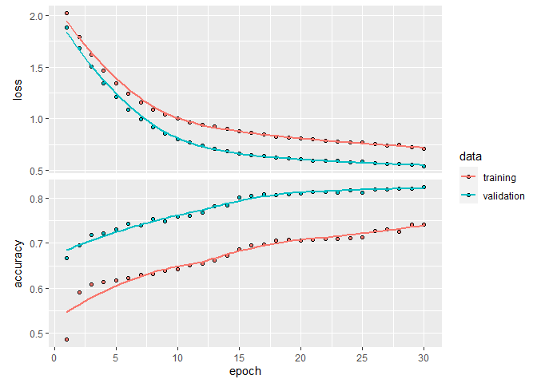

```r
set.seed(my_seed)
sigmoid_model <- keras_model_sequential()
sigmoid_model %>%
  layer_dense(units = 50, activation = 'softmax', input_shape = c(784)) %>%
  layer_dropout(rate = 0.2) %>%
  layer_dense(units = 10, activation = 'softmax')

compile(
  sigmoid_model,
  # Use this crossentropy loss function when there are two or more label classes.
  # Expected labels to be provided in a one_hot representation.
  loss = 'categorical_crossentropy',
  optimizer = optimizer_rmsprop(),
  metrics = c('accuracy')
)

# Add the data

history_2 <- fit(
  sigmoid_model,
  x_train, y_train,
  epochs = 30,
  batch_size = 250,
  validation_split = 0.3
)

plot(history_2)
```

### Adding another Relu layer to the neural network - relu_model_2

```r
set.seed(my_seed)
relu_model_2 <- keras_model_sequential()
relu_model_2 %>%
  layer_dense(units = 250, activation = 'relu', input_shape = c(784)) %>%
  layer_dropout(rate = 0.3) %>%
  layer_dense(units = 250, activation = 'relu') %>%
  layer_dropout(rate = 0.3) %>%
  layer_dense(units = 10, activation = 'softmax')

summary(relu_model_2)
```

```
## Model: "sequential_2"
## ________________________________________________________________________________
## Layer (type)                        Output Shape                    Param #
## ================================================================================
## dense_6 (Dense)                     (None, 250)                     196250
## ________________________________________________________________________________
## dropout_3 (Dropout)                 (None, 250)                     0
## ________________________________________________________________________________
## dense_5 (Dense)                     (None, 250)                     62750
## ________________________________________________________________________________
## dropout_2 (Dropout)                 (None, 250)                     0
## ________________________________________________________________________________
## dense_4 (Dense)                     (None, 10)                      2510
## ================================================================================
## Total params: 261,510
## Trainable params: 261,510
## Non-trainable params: 0
## ________________________________________________________________________________
```

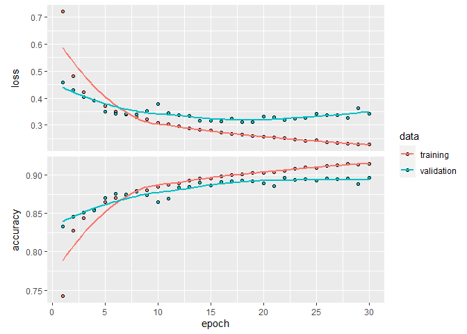

```r
compile(
  relu_model_2,
  loss = 'categorical_crossentropy',
  optimizer = optimizer_rmsprop(),
  metrics = c('accuracy')
)

history_3 <- fit(
  relu_model_2,
  x_train, y_train,
  epochs = 30,
  batch_size = 250,
  validation_split = 0.3
)

plot(history_3)
```

The following model showed pretty closed results to the base_model. However, with this one I would be a little bit more worried about overfitting

### Mixing the activation functions: (Adding different types of layers together - ReLu and SoftMax) - mix_model

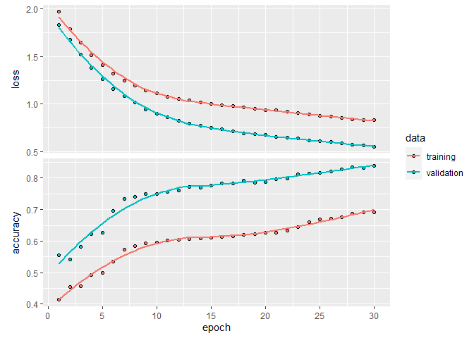

```r
set.seed(my_seed)
mix_model <- keras_model_sequential()
mix_model %>%
  layer_dense(units = 250, activation = 'relu', input_shape = c(784)) %>%
  layer_dropout(rate = 0.3) %>%
  layer_dense(units = 10, activation = 'softmax', input_shape = c(784)) %>%
  layer_dropout(rate = 0.2) %>%
  layer_dense(units = 10, activation = 'softmax')

compile(
  mix_model,
  loss = 'categorical_crossentropy',
  optimizer = optimizer_rmsprop(),
  metrics = c('accuracy')
)

history_4 <- fit(
  mix_model,
  x_train, y_train,
  epochs = 30,
  batch_size = 250,
  validation_split = 0.3
)

plot(history_4)
```

### Final Model - final_model

As the model number was performing greatly on the dataset, I have decided to enhance the number of layers units (nodes), reduce the batch size and increase the number of epochs.

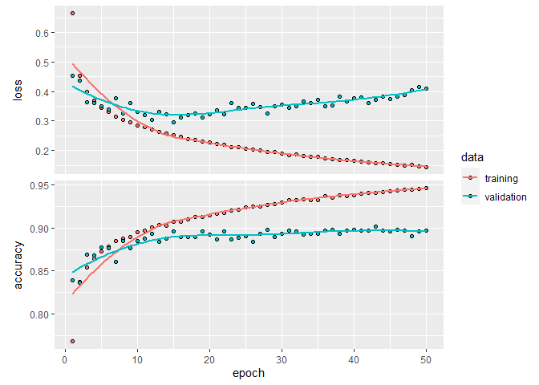

```r
set.seed(my_seed)
final_model <- keras_model_sequential()
final_model %>%
  layer_dense(units = 500, activation = 'relu', input_shape = c(784)) %>%
  layer_dropout(rate = 0.3) %>%
  layer_dense(units = 10, activation = 'softmax')

compile(
  final_model,
  loss = 'categorical_crossentropy',
  optimizer = optimizer_rmsprop(),
  metrics = c('accuracy')
)

history_5 <- fit(
  final_model,
  x_train, y_train,
  epochs = 50,
  batch_size = 200,
  validation_split = 0.3
)

plot(history_5)
```

### Summary

| base_model | sigmoid_model | relu_model_2 | mix_model | final_model |
| --- | --- | --- | --- | --- |
| 0.8821 | 0.7801 | 0.8808 | 0.7518 | 0.8882 |

## c) Evaluate the model on the test set

```r
evaluate(final_model, x_test, y_test)
```

```
##      loss  accuracy
## 0.4633199 0.8900000
```

The final accuracy on the test set was really close to 0.9, what is a really good result overall. At the end, it was really good to perceive that the results for the validation and the test set performed really close. The amount of observations between those sets were really similar (Validation - 18k and Test - 10k), assuring some sort of “stability” to the model predictions.

## d) Convulated network

The pre-processing required in a ConvNet is much lower as compared to other classification algorithms. While in primitive methods filters are hand-engineered, with enough training, ConvNets have the ability to learn these filters/characteristics.

In order to use the convulted network method let’s reset the datasets and move them back to an array and turn them into a 3D shape to max pooling and 2D convolutional layer processing. After this stage the data is flattened into a 1D shape for the dense network part of all the neural net models.

```r
# Switching the datasets to a 3D shape for pooling a 2D convolutional layer processing.

x_train <- fashion_mnist$train$x
x_test <- fashion_mnist$test$x

x_train <- array_reshape(x_train, c(nrow(x_train), 28, 28, 1))
x_test <- array_reshape(x_test, c(nrow(x_test), 28, 28, 1))

x_train <- x_train / 255
x_test <- x_test / 255
```

### Bulding the base model - cnn_base_model

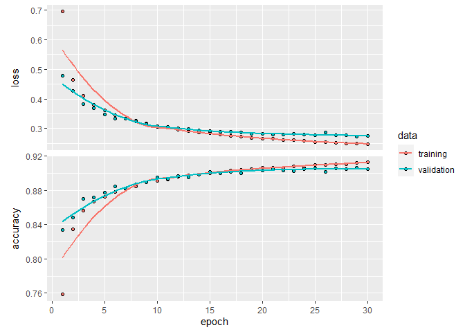

```r
set.seed(my_seed)
cnn_base_model <- keras_model_sequential()
cnn_base_model %>%
  # The kernel size here refers to the widthxheight of the filter mask.
  # Returns the pixel with maximum value from a set of pixels within a mask (kernel).
  # That kernel is swept across the input, subsampling it.
  layer_conv_2d(
    filters = 32,  # This is closer to what we have seen as the number of nodes
    kernel_size = c(3, 3), # max the input based on 3x3 squares
    activation = 'relu',
    input_shape = c(28, 28, 1)
  ) %>%
 # Downsamples the input representation by taking the maximum value over the window defined by pool_size for each dimension along the features axis
  layer_max_pooling_2d(pool_size = c(2, 2)) %>% # In this case is downsampling by (2x2)
  layer_dropout(rate = 0.25) %>%
 # Flatten is the function that converts the pooled feature map to a single column (vector) that is passed to the fully connected layer.
  layer_flatten() %>%
  layer_dropout(rate = 0.25) %>%
  layer_dense(units = 10, activation = 'softmax')

compile(
  cnn_base_model,
  loss = 'categorical_crossentropy',
  optimizer = optimizer_rmsprop(),
  metrics = c('accuracy')
)

history_6 <- fit(
  cnn_base_model, x_train, y_train,
  epochs = 30, batch_size = 250,
  validation_split = 0.3
)

plot(history_6)
```

Our base model in this scenario already shows really great results, however it’s important to mention that the model may be overfitting the validation data set. It uses 32 filters, a 3x3 kernel size, 30 epochs, batch_size = 250 and it’s max pooling in 2x2. All those parameters mentioned will repeat for the other upcoming models.

### Adding an Extra Max Pooling - cnn_extraMax

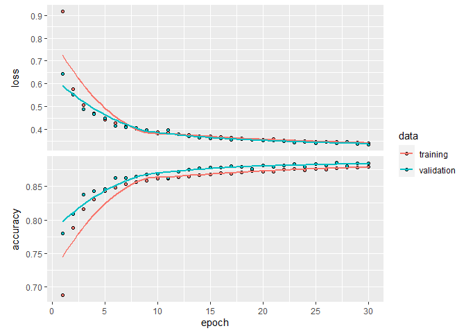

```r
set.seed(my_seed)
cnn_extraMax <- keras_model_sequential()
cnn_extraMax %>%
  layer_conv_2d(
    filters = 32,
    kernel_size = c(3, 3),
    activation = 'relu',
    input_shape = c(28, 28, 1)
  ) %>%
  layer_max_pooling_2d(pool_size = c(2, 2)) %>%
  layer_dropout(rate = 0.25) %>%
  layer_max_pooling_2d(pool_size = c(2, 2)) %>%
  layer_dropout(rate = 0.25) %>%
  layer_flatten() %>%
  layer_dense(units = 10, activation = 'softmax')

compile(
  cnn_extraMax,
  loss = 'categorical_crossentropy',
  optimizer = optimizer_rmsprop(),
  metrics = c('accuracy')
)

history_7 <- fit(
  cnn_extraMax, x_train, y_train,
  epochs = 30, batch_size = 250,
  validation_split = 0.3
)

plot(history_7)
```

Adding another max pooling reduced the accuracy of our model, what could be expected considering that the Maxpool removes information from the signal, dropout forces distributed representation, thus both effectively make it harder to propagate information. However, the model itself is a bit less prone to overfitting.

### Adding a Relu before the final output Layer - cnn_ReLu

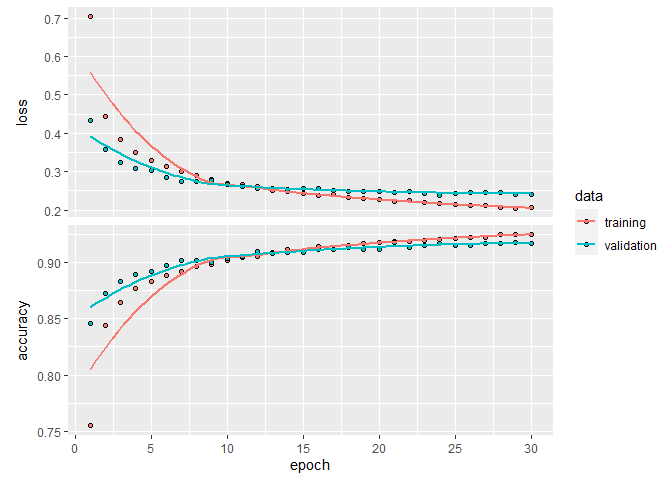

```r
set.seed(my_seed)
cnn_ReLu <- keras_model_sequential()
cnn_ReLu  %>%
  layer_conv_2d(
    filters = 32,
    kernel_size = c(3, 3),
    activation = 'relu',
    input_shape = c(28, 28, 1)
  ) %>%
  layer_max_pooling_2d(pool_size = c(2, 2)) %>% # In this case is downsampling by (2x2)
  layer_dropout(rate = 0.25) %>%
  layer_flatten() %>%
  layer_dropout(rate = 0.25) %>%
  layer_dense(units = 50, activation = 'relu') %>%
  layer_dropout(rate = 0.25) %>%
  layer_dense(units = 10, activation = 'softmax')

compile(
  cnn_ReLu,
  loss = 'categorical_crossentropy',
  optimizer = optimizer_rmsprop(),
  metrics = c('accuracy')
)

history_8 <- fit(
  cnn_ReLu, x_train, y_train,
  epochs = 30, batch_size = 250,
  validation_split = 0.3
)

plot(history_8)
```

Adding the a ReLu layer before the final output layer slightly improved the accuracy of our model. Although, it’s important to mention that the model is still possibly overfitting the dataset based on the results obtained in the validation dataset.

### Adding an extra Max Pooling and a ReLu before the output Layer - cnn_extraMax_ReLu

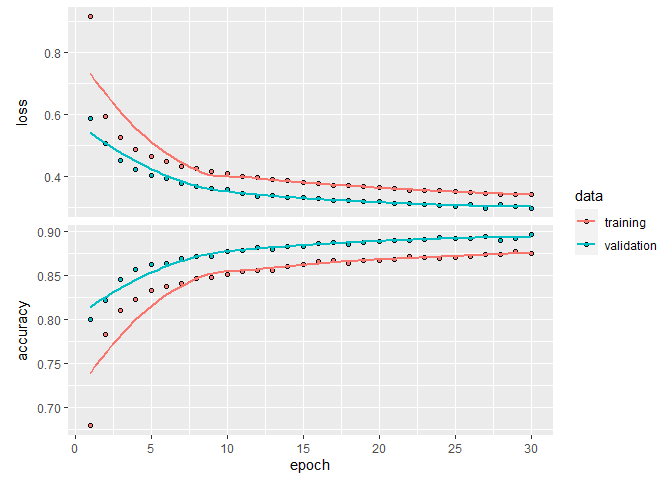

```r
set.seed(my_seed)
cnn_extraMax_ReLu <- keras_model_sequential()
cnn_extraMax_ReLu  %>%
  layer_conv_2d(
    filters = 32,
    kernel_size = c(3, 3),
    activation = 'relu',
    input_shape = c(28, 28, 1)
  ) %>%
  layer_max_pooling_2d(pool_size = c(2, 2)) %>%
  layer_dropout(rate = 0.25) %>%
  layer_max_pooling_2d(pool_size = c(2, 2)) %>%
  layer_dropout(rate = 0.25) %>%
  layer_flatten() %>%
  layer_dropout(rate = 0.25) %>%
  layer_dense(units = 50, activation = 'relu') %>%
  layer_dropout(rate = 0.25) %>%
  layer_dense(units = 10, activation = 'softmax')

compile(
  cnn_extraMax_ReLu,
  loss = 'categorical_crossentropy',
  optimizer = optimizer_rmsprop(),
  metrics = c('accuracy')
)

history_9 <- fit(
  cnn_extraMax_ReLu, x_train, y_train,
  epochs = 30, batch_size = 250,
  validation_split = 0.3
)

plot(history_9)
```

This final model showed results similar to the base model (great accuracy), however due to the addition of the Max Pooling function the model is way less inclined to overfitting.

### Summary

| cnn_base_model | cnn_extraMax | cnn_ReLu | cnn_extraMax_ReLu |
| --- | --- | --- | --- |
| 0.8926 | 0.8673 | 0.9051 | 0.8766 |

The best is actually model cnn_Relu, but we still need to check how it`s performing in the test set.

```r
evaluate(cnn_ReLu, x_test, y_test)
```

```
##      loss  accuracy
## 0.2542503 0.9131000
```

On the same way that have happened with the neural networks the accuracy on the test set was really close to 0.9, what is a really good result overall. At the end, it was really good to perceive that the results for the validation and the test set performed really close. The amount of observations between those sets were really similar (Validation - 18k and Test - 10k), assuring some sort of “stability” to the model predictions.